# Final Models — Linear + Non-Linear Price Prediction

## Global feature importance — SHAP beeswarm

The beeswarm shows **how each feature moves the prediction across the entire test set**. Each row is a feature; each dot is one test property; horizontal position is that property’s SHAP value (contribution to log price, roughly a % premium / discount); colour is the feature value (red = high, blue = low).

Features are sorted by mean |SHAP| — the ones at the top matter most globally. Read a row as: “high values of this feature push price up when red, and down when blue.”

```python
explainer = shap.TreeExplainer(nl_model)
sv_test   = explainer.shap_values(X_test)
base_val  = (float(explainer.expected_value)
             if np.isscalar(explainer.expected_value)
             else float(explainer.expected_value[0]))
print(f"SHAP matrix: {sv_test.shape}   "
      f"base value E[ln price] = {base_val:.4f}  ≈ ${np.exp(base_val):,.0f}")
```

```
SHAP matrix: (2500, 101)   base value E[ln price] = 12.8621  ≈ $385,433
```

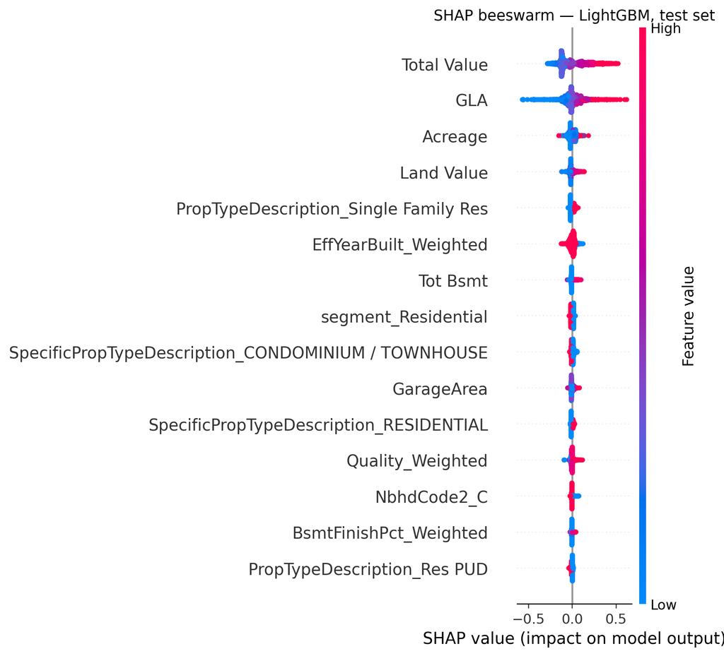

```python
# Relabel columns to human-readable names for the plot only
X_test_pretty = X_test.rename(columns=ORIG_OF)
shap.summary_plot(sv_test, X_test_pretty, max_display=15, show=False)
plt.title("SHAP beeswarm — LightGBM, test set")
plt.tight_layout(); plt.show()
```

## Local interpretability — how to read a waterfall

A **waterfall plot** shows how the model priced *one specific property*. The bottom bar is the training-set mean log-price — every property starts there. Each subsequent bar is one feature’s push on the prediction: positive bars (red) add dollars, negative bars (blue) take them away. The top bar is the model’s final prediction.

Think of it as an X-ray: it shows *why* the model gave the quote it did. Use this exact code pattern in the UI whenever a user clicks “explain this estimate.”

### Median residential — a typical home

```python
# Median-priced residential and a high-end residential property from the test set
tb = pd.DataFrame({'seg': seg_test.values,
                   'y':   y_test.values,
                   'pred': nl_model.predict(X_test)})
med_res_idx = (tb[tb['seg']=='Residential']
               .assign(r=lambda d: np.abs(d['y'] - d['y'].median()))
               .nsmallest(1, 'r').index[0])
lux_res_idx = tb[tb['seg']=='Residential'].nlargest(1, 'y').index[0]

for idx, lbl in [(med_res_idx, 'Median residential'),
                 (lux_res_idx, 'Luxury residential')]:
    p = float(nl_model.predict(X_test.iloc[idx:idx+1])[0])
    a = float(y_test.iloc[idx])
    print(f"  {lbl:22s}  predicted ${np.exp(p):>10,.0f}   "
          f"actual ${np.exp(a):>10,.0f}")
```

```
  Median residential      predicted $   373,364   actual $   368,823
  Luxury residential      predicted $   727,945   actual $ 1,042,858
```

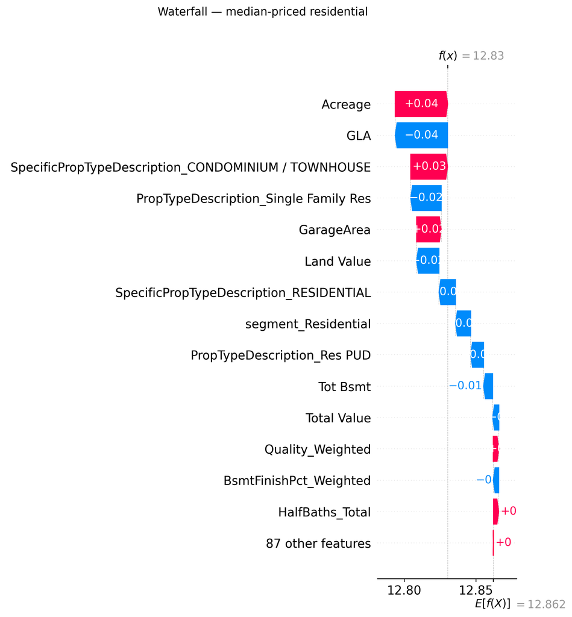

```python
shap.plots._waterfall.waterfall_legacy(
    expected_value=base_val,
    shap_values=sv_test[med_res_idx],
    features=X_test.iloc[med_res_idx].values,
    feature_names=[ORIG_OF[c] for c in X_test.columns],
    max_display=15, show=False)
plt.suptitle("Waterfall — median-priced residential", y=1.02)
plt.tight_layout(); plt.show()
```

### Luxury residential — what drives a high quote

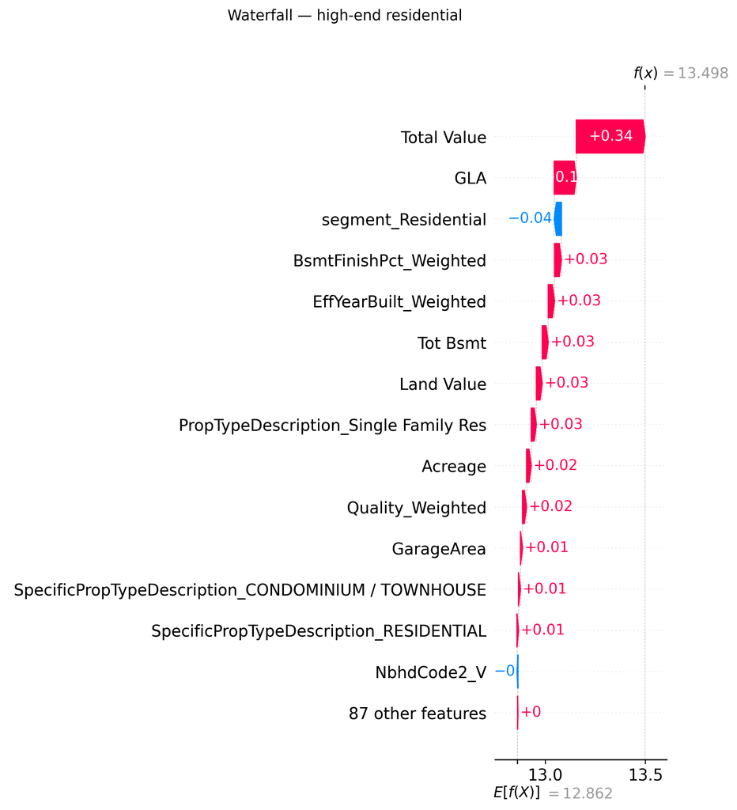

```python
shap.plots._waterfall.waterfall_legacy(
    expected_value=base_val,
    shap_values=sv_test[lux_res_idx],
    features=X_test.iloc[lux_res_idx].values,
    feature_names=[ORIG_OF[c] for c in X_test.columns],
    max_display=15, show=False)
plt.suptitle("Waterfall — high-end residential", y=1.02)
plt.tight_layout(); plt.show()
```

## `predict_price_nonlinear(**features)`

```python
# Per-segment medians of NUMERIC features (defaults when a field is omitted)
NUM_FEATS = ['GLA','EffYearBuilt_Weighted','Acreage','Tot Bsmt','GarageArea',
             'CarportArea','SqFt_DetGarage','SqFt_DetCarport','Sqft_Barn',
             'SqFt_Guest_House','SqFt_Pools','SqFt_Recreational_Courts',
             'SqFt_Shed','SqFt_Gazebo_Pavilion','FullBaths_Total',
             'HalfBaths_Total','GarageCapacity',
             'Land Value','Total Value','Quality_Weighted',
             'BsmtFinishPct_Weighted']
NUM_FEATS = [c for c in NUM_FEATS if c in df_nl.columns]

_df_nums = df_nl[NUM_FEATS].copy()
for c in NUM_FEATS:
    # Unconditional — astype(str) is safe even for already-numeric cols.
    cl = _df_nums[c].astype(str).str.replace(r'[\$,\s]', '', regex=True)
    _df_nums[c] = pd.to_numeric(cl, errors='coerce').astype('float64')
_df_nums['segment'] = df_nl['segment'].values
NL_SEG_DEFAULTS = _df_nums.groupby('segment')[NUM_FEATS].median().to_dict(orient='index')

# Per-segment log-residual quantiles for 95 % prediction intervals
_res_global_nl = y_test.values - nl_model.predict(X_test)
_q_global_nl   = tuple(np.quantile(_res_global_nl, [0.025, 0.975]))
NL_PI_Q = {}
for s in seg_test.unique():
    m = (seg_test == s).values
    if m.sum() >= 20:
        r = y_test[m].values - nl_model.predict(X_test.loc[m])
        NL_PI_Q[s] = tuple(np.quantile(r, [0.025, 0.975]))
    else:
        NL_PI_Q[s] = _q_global_nl

NL_CATEGORICALS = {'PropTypeDescription','SpecificPropTypeDescription',
                   'NbhdCode2','Main_StyleDesc','segment'}

def _nl_set_dummy(row, prefix, value):
    """Flip the cleaned one-hot column that matches prefix_value."""
    if value is None: return
    target = _clean(f"{prefix}_{value}")
    if target in row.index:
        row[target] = 1; return
    # Fallback: case-insensitive tail match
    for c in row.index:
        if c.startswith(prefix + '_'):
            tail = c[len(prefix) + 1:]
            if _clean(tail).lower() == _clean(str(value)).lower():
                row[c] = 1; return

def predict_price_nonlinear(**feats):
    """
    Predict property price with the LightGBM model.

    Accepts raw, human-readable feature names. Missing features fall
    back to the training-set median for the requested `segment`.

    Returns
    -------
    dict with keys:
      pred          : float — dollar prediction
      pi_lo, pi_hi  : float — 95 % prediction interval bounds (dollars)
      log_pred      : float — prediction on the log scale
      log_base      : float — model's baseline log-price (segment-blind)
      segment_used  : str
      top_contribs  : list of (feature_name, shap_log, feat_value)
                      — the 5 biggest drivers of this specific quote,
                        ready for "why did the model say this?" UI.
    """
    segment = feats.pop('segment', 'Residential')

    row = pd.Series(0.0, index=X_train.columns)
    # Fill segment-median defaults
    for k, v in NL_SEG_DEFAULTS.get(segment, {}).items():
        cl = _clean(k)
        if cl in row.index:
            row[cl] = v
    # Flip segment dummy
    if f'segment_{segment}' in row.index:
        row[f'segment_{segment}'] = 1

    # Apply caller overrides
    for k, v in feats.items():
        if k in NL_CATEGORICALS:
            _nl_set_dummy(row, k, v)
        else:
            cl = _clean(k)
            if cl in row.index:
                row[cl] = float(v)

    X_row = row.to_frame().T
    log_pred = float(nl_model.predict(X_row)[0])
    q_lo, q_hi = NL_PI_Q.get(segment, _q_global_nl)

    # Top-5 SHAP contributions for the UI to show "why"
    sv = explainer.shap_values(X_row)[0]
    order = np.argsort(-np.abs(sv))[:5]
    top_contribs = [(ORIG_OF[X_train.columns[i]],
                     float(sv[i]), float(row.iloc[i]))
                    for i in order]

    return dict(
        pred=float(np.exp(log_pred)),
        pi_lo=float(np.exp(log_pred + q_lo)),
        pi_hi=float(np.exp(log_pred + q_hi)),
        log_pred=log_pred,
        log_base=base_val,
        segment_used=segment,
        top_contribs=top_contribs,
    )
```

## Example call — non-linear

```python
r = predict_price_nonlinear(
    segment='Residential',
    PropTypeDescription='Single Family Res',
    GLA=2400, EffYearBuilt_Weighted=2005,
    Acreage=0.25, **{'Tot Bsmt': 800}, GarageArea=500,
    FullBaths_Total=2, HalfBaths_Total=1, GarageCapacity=2,
    Quality_Weighted=4.0)
print(f"LightGBM prediction : ${r['pred']:,.0f}")
print(f"95% interval        : [${r['pi_lo']:,.0f}, ${r['pi_hi']:,.0f}]")
print(f"Segment used        : {r['segment_used']}")
print("\nTop 5 drivers of this quote (log-price contributions):")
for name, shap_val, feat_val in r['top_contribs']:
    print(f"  {name:42s}  value={feat_val:>12,.3f}   Δlog={shap_val:+.4f}")
```

```
LightGBM prediction : $426,210
95% interval        : [$363,495, $506,102]
Segment used        : Residential

Top 5 drivers of this quote (log-price contributions):
  GLA                                         value=   2,400.000   Δlog=+0.0858
  Total Value                                 value= 323,188.000   Δlog=-0.0617
  Quality_Weighted                            value=       4.000   Δlog=+0.0443
  Acreage                                     value=       0.250   Δlog=+0.0335
  EffYearBuilt_Weighted                       value=   2,005.000   Δlog=-0.0290
```

# Hand-off Summary

[output not shown]

**UI Notes**